## Peer Grader Guidance

Please review the student expectations for peer review grading and peer review comments. Overall, we ask that you score with accuracy. When grading your peers, you will not only learn how to improve your future homework submissions but you will also gain deeper understanding of the concepts in the assignments. When assigning scores, consider the responses to the questions given your understanding of the problem and using the solutions as a guide. Moreover, please give partial credit for a concerted effort, but also be thorough. **Add comments to your review, particularly when deducting points, to explain why the student missed the points.** Ensure your comments are specific to questions and the student responses in the assignment.

# Background

The provided dataset is a subset of the public data from the 2022 EPA Automotive Trends Report. It will be used to study the effects of various vehicle characteristics on CO2 emissions.

## Data Description

The dataset consists of a dataframe with 1703 observations with the following 7 variables:

1. Model.Year: year the vehicle model was produced (quantitative)
2. Type: vehicle type (qualitative)
3. MPG: miles per gallon of fuel (quantitative)
4. Weight: vehicle weight in lbs (quantitative)
5. Horsepower: vehicle horsepower in HP (quantitative)
6. Acceleration: acceleration time (from 0 to 60 mph) in seconds (quantitative)
7. CO2: carbon dioxide emissions in g/mi (response variable)

## Instructions on reading the data

To read the data in `R`, save the file in your working directory (make sure you have changed the directory if different from the R working directory) and read the data using the `R` function `read.csv()`

```r
# reading the dataset
library(dplyr)
data <- read.csv("data/emissions.csv")
head(data,3)
```

```
##   Model.Year Type      MPG   Weight Horsepower Acceleration      CO2
## 1       2008  Van 20.39302 4500.000   241.8963       8.9064 435.7864
## 2       2009  Van 20.39440 4835.321   241.9881       9.0603 435.7570
## 3       2010  Van 20.17616 4840.431   244.0000       9.1116 440.4703
```

# Question 1: Exploratory Data Analysis [15 points]

1. **3 pts** Compute the correlation coefficient for each quantitative predicting variable (Model.Year, MPG, Weight, Horsepower, Acceleration) against the response (CO2). Describe the strength and direction of the top 3 predicting variables that have the strongest linear relationships with the response.

```r
cor(data$Model.Year, data$CO2)
```

```
## [1] -0.3683023
```

```r
cor(data$MPG, data$CO2)
```

```
## [1] -0.9590643
```

```r
cor(data$Weight, data$CO2)
```

```
## [1] 0.5930236
```

```r
cor(data$Horsepower, data$CO2)
```

```
## [1] 0.1102096
```

```r
cor(data$Acceleration, data$CO2)
```

```
## [1] 0.235064
```

**Q1a ANSWER:**

*Correlations Coefficients:*

- **CO2 and Model.Year:** -0.3683023
- **CO2 and MPG:** -0.9590643
- **CO2 and Weight:** 0.5930236
- **CO2 and Horsepower:** 0.1102096
- **CO2 and Acceleration:** 0.235064

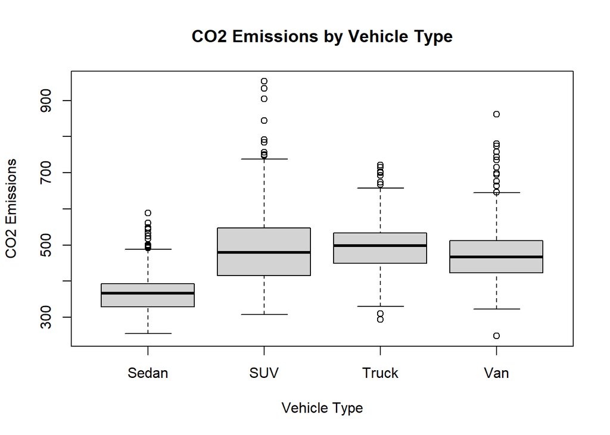

```r
boxplot(
  CO2 ~ Type,
  data = data,
  main = "CO2 Emissions by Vehicle Type",
  xlab = "Vehicle Type",
  ylab = "CO2 Emissions"
)
```

**Q1b ANSWER:**

- Sedans have the lowest median CO2 emissions and relatively low variability in comparison.
- Trucks have highest median CO2 emissions.
- SUVs shows greatest variability in CO2 emissions.
- Vans are similar to Trucks, but have more high-emission outliers.
3. **6 pts** Create scatterplots of the response (CO2) against each quantitative predicting variable (Model.Year, MPG, Weight, Horsepower, Acceleration). Describe the general trend of each plot.

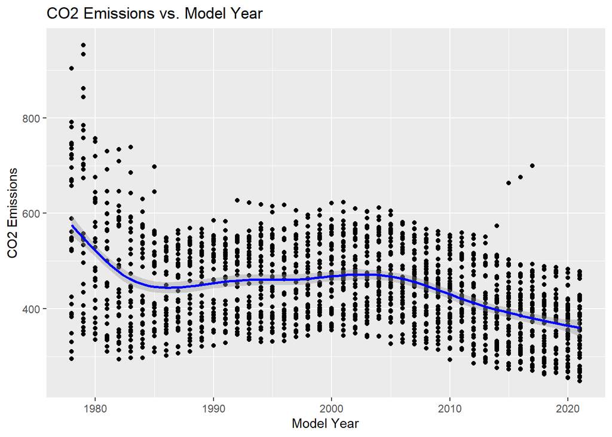

```r
library(ggplot2)

# Model.Year vs CO2
ggplot(data, aes(x = Model.Year, y = CO2)) +
  geom_point() +
  geom_smooth(color = "blue") +
  labs(title = "CO2 Emissions vs. Model Year", x = "Model Year", y = "CO2 Emissions")
```

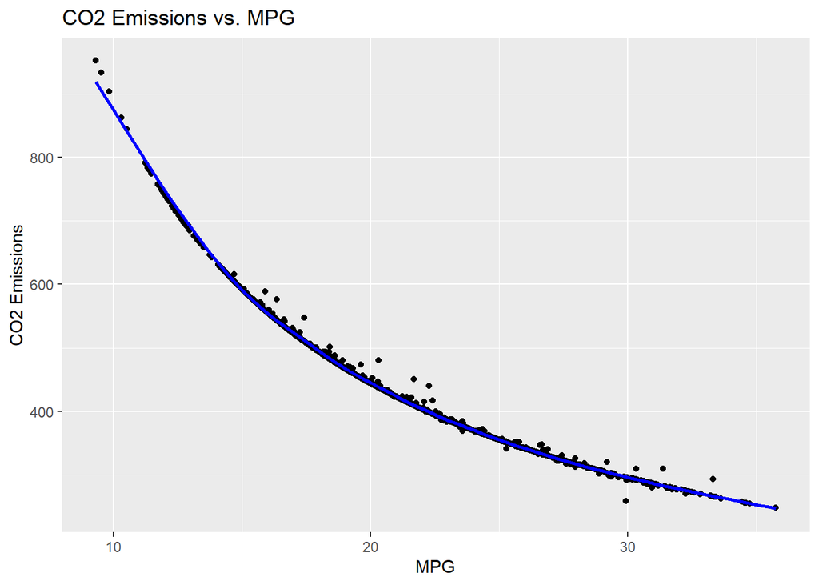

```r
# MPG vs CO2
ggplot(data, aes(x = MPG, y = CO2)) +
  geom_point() +
  geom_smooth(color = "blue") +
  labs(title = "CO2 Emissions vs. MPG", x = "MPG", y = "CO2 Emissions")
```

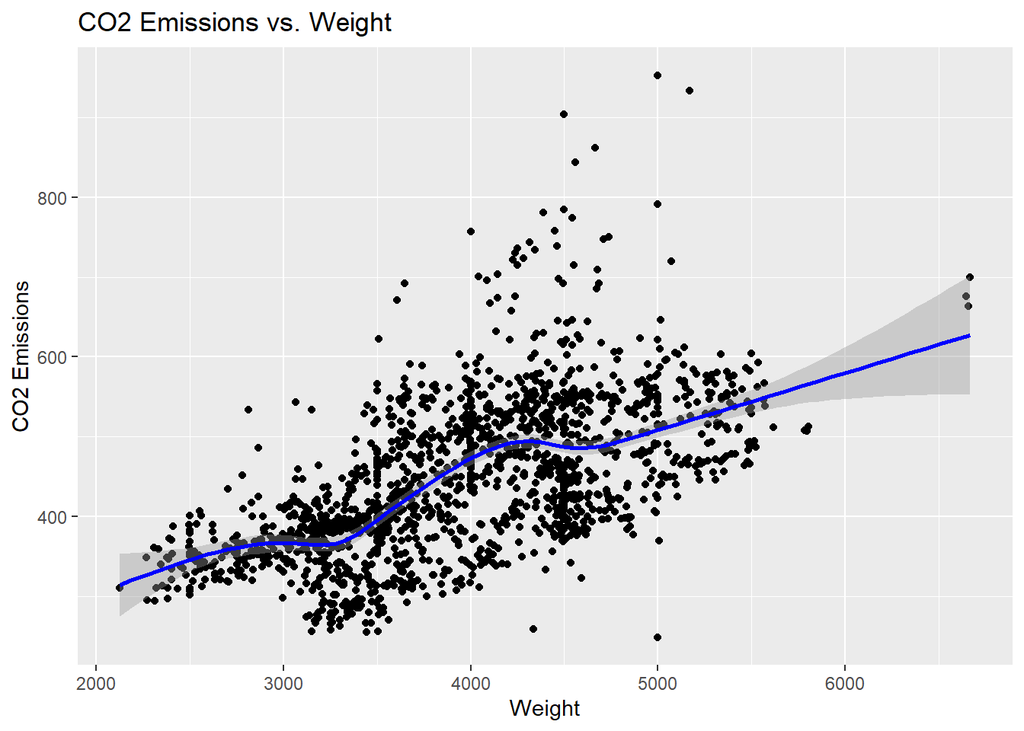

```r
# Weight vs CO2
ggplot(data, aes(x = Weight, y = CO2)) +
  geom_point() +
  geom_smooth(color = "blue") +
  labs(title = "CO2 Emissions vs. Weight", x = "Weight", y = "CO2 Emissions")
```

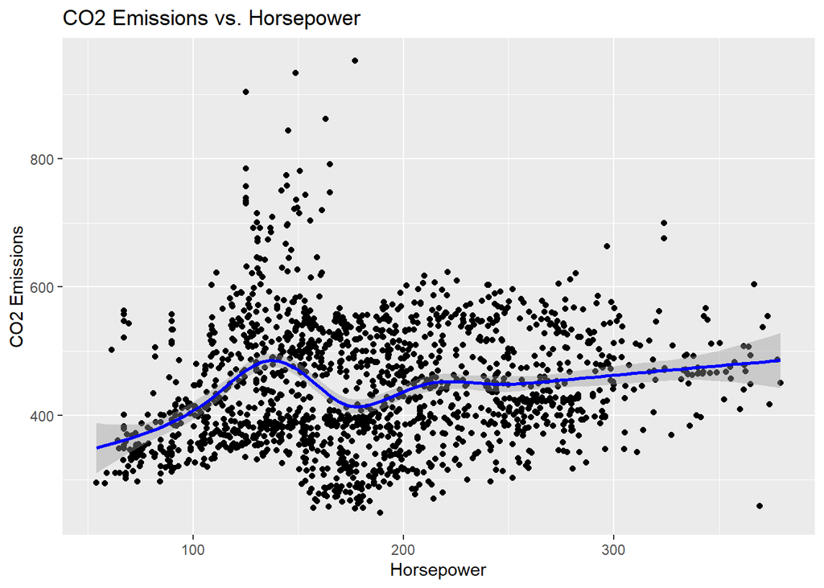

```r
# Horsepower vs CO2
ggplot(data, aes(x = Horsepower, y = CO2)) +
  geom_point() +
  geom_smooth(color = "blue") +
  labs(title = "CO2 Emissions vs. Horsepower", x = "Horsepower", y = "CO2 Emissions")
```

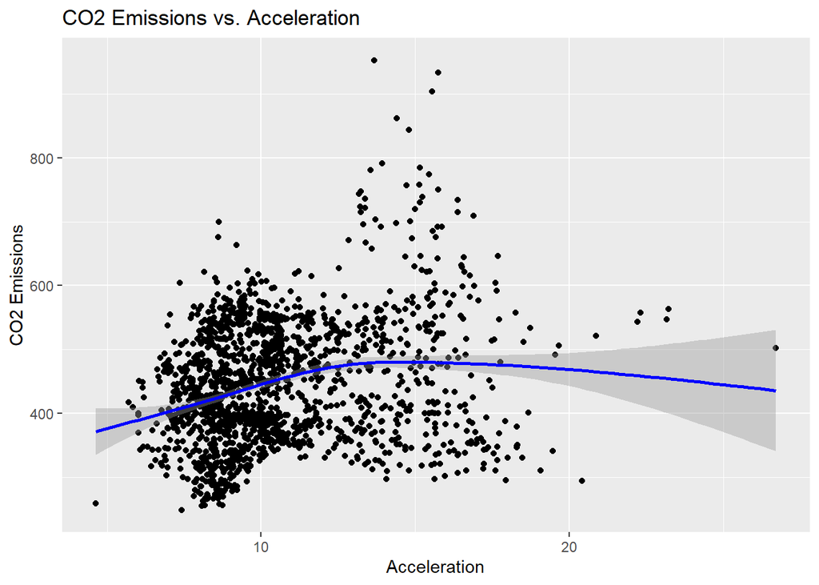

```r
# Acceleration vs CO2
ggplot(data, aes(x = Acceleration, y = CO2)) +
  geom_point() +
  geom_smooth(color = "blue") +
  labs(title = "CO2 Emissions vs. Acceleration", x = "Acceleration", y = "CO2 Emissions")
```

**Q1c ANSWER:**

Yes, but with the condition that the transformations are applied to improve fit, since it appears the assumptions on linearity and constant variance are challenged. Also, not all the predictors may be useful: i.e. acceleration data seems unclear, and therefore may not need be needed to predict CO2. Additionally, examining the residuals after fitting a model would be essential to check for linearity, constant variance, normality, and independence.

# Question 2: Model Fitting and Interpretation [26 points]

1. **3 pts** Fit a multiple linear regression model called model1 using CO2 as the response and the top 3 predicting variables with the strongest relationship with CO2, from Question 1a.

```r
model1 <- lm(CO2 ~ MPG + Weight + Model.Year, data = data)
summary(model1)
```

```
##
## Call:
## lm(formula = CO2 ~ MPG + Weight + Model.Year, data = data)
##
## Residuals:
##     Min      1Q  Median      3Q     Max
## -39.564 -14.362  -6.149   6.326 254.785
##
## Coefficients:
##               Estimate Std. Error t value Pr(>|t|)
## (Intercept)  3.875e+03  1.952e+02   19.86   <2e-16 ***
## MPG         -1.629e+01  3.359e-01  -48.49   <2e-16 ***
## Weight       2.850e-02  2.084e-03   13.68   <2e-16 ***
## Model.Year  -1.600e+00  1.040e-01  -15.39   <2e-16 ***
## ---
## Signif. codes:  0 '***' 0.001 '**' 0.01 '*' 0.05 '.' 0.1 ' ' 1
##
## Residual standard error: 25.17 on 1699 degrees of freedom
## Multiple R-squared:  0.9296, Adjusted R-squared:  0.9295
## F-statistic:  7482 on 3 and 1699 DF,  p-value: < 2.2e-16
```

2. **4 pts** What is the estimated coefficient for the intercept? Interpret this coefficient in the context of the dataset.

**Q2b ANSWER:**

The estimated coefficient for the intercept is 3.875 kg/mi CO2 if MPG, Weight, and Model-Year are set to zero. Interpreting this is a bit abstract since it’s obviously not physically possible to have a car with zero weight, zero MPG, or from the year zero. But this serves as a baseline from which the effects of the predictors are measured. Because for every additional unit increase in the predictors, the CO2 emissions are expected to increase/decrease by the coefficients from this baseline.

3. **4 pts** Assuming a marginal relationship between Type and CO2, perform an ANOVA F-test on the mean CO2 emission among the different vehicle types. Using an $\alpha$-level of 0.05, is Type useful in predicting CO2? Explain how you determined the answer.

```r
aov_model <- aov(CO2 ~ Type, data = data)
summary(aov_model)
```

```
##               Df  Sum Sq Mean Sq F value Pr(>F)
## Type           3 5598255 1866085   326.9 <2e-16 ***
## Residuals   1699 9699291    5709
## ---
## Signif. codes:  0 '***' 0.001 '**' 0.01 '*' 0.05 '.' 0.1 ' ' 1
```

**Q2c ANSWER:**

- Null hypothesis: no relationship between CO2 and Type
- p-value ~ 0, which is less than alpha-level of 0.05.
- Therefore, we reject the null hypothesis, concluding that Type is useful for predicting CO2.
4. **3 pts** Fit a multiple linear regression model called model2 using CO2 as the response and all predicting variables. Using $\alpha = 0.05$, which of the estimated coefficients that were statistically significant in model1 are also statistically significant in model2?

```r
model2 <- lm(CO2 ~ ., data = data)
summary(model2)
```

```
##
## Call:
## lm(formula = CO2 ~ ., data = data)
##
## Residuals:
##     Min      1Q  Median      3Q     Max
## -49.969 -12.299  -4.040   6.126 242.173
##
## Coefficients:
##                Estimate Std. Error t value Pr(>|t|)
## (Intercept)   1.250e+03  2.983e+02   4.190 2.94e-05 ***
## Model.Year   -2.859e-01  1.525e-01  -1.875   0.0609 .
## TypeSUV      -1.594e+01  2.199e+00  -7.249 6.35e-13 ***
## TypeTruck    -1.802e+01  2.201e+00  -8.186 5.24e-16 ***
## TypeVan      -3.082e+01  2.397e+00 -12.854  < 2e-16 ***
## MPG          -1.749e+01  3.507e-01 -49.882  < 2e-16 ***
## Weight        4.978e-02  2.588e-03  19.235  < 2e-16 ***
## Horsepower   -3.460e-01  2.918e-02 -11.858  < 2e-16 ***
## Acceleration  1.333e+00  5.516e-01   2.417   0.0158 *
## ---
## Signif. codes:  0 '***' 0.001 '**' 0.01 '*' 0.05 '.' 0.1 ' ' 1
##
## Residual standard error: 23.3 on 1694 degrees of freedom
## Multiple R-squared:  0.9399, Adjusted R-squared:  0.9396
## F-statistic:  3309 on 8 and 1694 DF,  p-value: < 2.2e-16
```

**Q2d ANSWER:**

MPG and Weight are statistically significant in model1 and model2. It appears that Model.Year in model2 has a p-value of 0.0609, which is not statistically significant at the alpha-level of 0.05, despite it being so in model1.

5. **4 pts** Interpret the estimated coefficient for TypeSUV in the context of the dataset. Make sure TypeSedan is the baseline level for Type. Mention any assumptions you make about other predictors clearly when stating the interpretation.

**Q2e ANSWER:**

Assuming all other variables in the model (Model.Year, MPG, Weight, Horsepower, and Acceleration) are held constant, an SUV is expected to emit 15.94 g/mi less CO2 than a Sedan, on average.

6. **4 pts** How does your interpretation of TypeSUV above compare to the relationship between CO2 vs Type analyzed using the boxplot in Q1? Explain the reason for the similarities/differences.

**Q2f ANSWER:**

The negative relationship might seem counter-intuitive, since we may expect SUVs to emit more CO2 than Sedans, as seen in the box plot - but it does not appear to be case here. However, the model includes other variables that already account for differences in emissions due to vehicle size, power, etc. So, the coefficient for TypeSUV is the difference in emissions that is not explained by these other factors. Additionally, the model above is not transformed and does not include interaction effects.

7. **4 pts** Is the overall regression (model2) significant at an $\alpha$-level of 0.05? Explain how you determined the answer.

**Q2g ANSWER:**

- Null hypothesis: no relationship between CO2 and all predictors
- p-value ~ 0 (<2.2e-16), which is less than alpha-level of 0.05.
- Therefore, we reject the null hypothesis, concluding that the model as a whole is significant.

# Question 3: Model Comparison, Outliers, and Multicollinearity [16 points]

1. **4 pts** Conduct a partial $F$-test comparing model1 and model2. What can you conclude from the results using an $\alpha$-level of 0.05?

```r
anova(model1, model2)
```

```
## Analysis of Variance Table
##
## Model 1: CO2 ~ MPG + Weight + Model.Year
## Model 2: CO2 ~ Model.Year + Type + MPG + Weight + Horsepower + Acceleration
##   Res.Df     RSS Df Sum of Sq      F    Pr(>F)
## 1   1699 1076422
## 2   1694  919983  5    156440 57.612 < 2.2e-16 ***
## ---
## Signif. codes:  0 '***' 0.001 '**' 0.01 '*' 0.05 '.' 0.1 ' ' 1
```

**Q3a ANSWER:**

- Null hypothesis: additional predictors in model2 do not significantly improve the prediction of CO2, compared to model1.
- p-value ~ 0 (<2.2e-16), which is less than alpha-level of 0.05.
- Therefore, we reject the null hypothesis, concluding that additional predictors in model2 improve the prediction of CO2.

This means that the variables added in model2 contribute additional valuable information for the prediction of CO2 emissions that is not captured by the variables in model1.

2. **4 pts** Using $R^2$ and adjusted $R^2$, compare model1 and model2.

```r
# model 1 vals
summary_model1 <- summary(model1)
r_squared_model1 <- summary_model1$r.squared
adjusted_r_squared_model1 <- summary_model1$adj.r.squared

# model 2 vals
summary_model2 <- summary(model2)
r_squared_model2 <- summary_model2$r.squared
adjusted_r_squared_model2 <- summary_model2$adj.r.squared

# output
cat("model1 - R^2:", r_squared_model1, "- Adjusted R^2:", adjusted_r_squared_model1, "\n")
```

```
## model1 - R^2: 0.9296343 - Adjusted R^2: 0.9295101
```

```r
cat("model2 - R^2:", r_squared_model2, "- Adjusted R^2:", adjusted_r_squared_model2, "\n")
```

```
## model2 - R^2: 0.9398608 - Adjusted R^2: 0.9395768
```

**Q3b ANSWER:**

Both $R^2$ and adjusted $R^2$ models are very good. However, model2 has a slightly higher $R^2$ and adjusted $R^2$. It is expected for the $R^2$ value to increase since there are more predictors; however, the adjusted $R^2$ also increased, which accounts for increased number of predictors, which justifies that the increased number of predictors in model2 better fits the data.

3. **4 pts** Create a plot for the Cook’s Distances (use model2). Using a threshold of 1, are there any outliers? If yes, which data points?

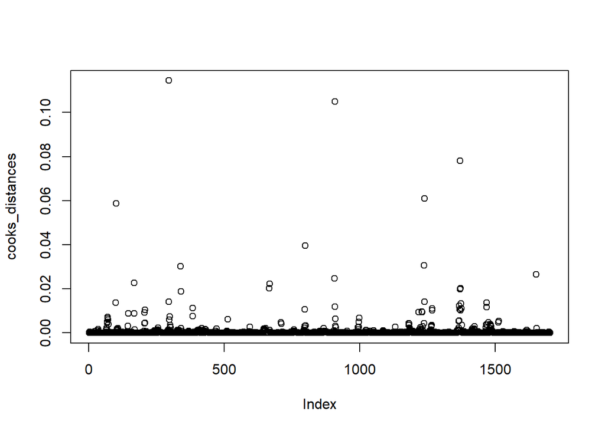

```r
cooks_distances  <- cooks.distance(model2)
plot(cooks_distances)
```

**Q3c ANSWER:**

The top of the graph ends at 0.12, which is below the Cook’s Distance of 1. Therefore, there are no outliers.

4. **4 pts** Calculate the VIF of each predictor (use model2). Using a threshold of max(10, 1/(1-$R^2$)) what conclusions can you make regarding multicollinearity?

```r
library(car)
# calculate vif
vif(model2) %>% print()
```

```
##                   GVIF Df GVIF^(1/(2*Df))
## Model.Year   11.158497  1        3.340434
## Type          3.285619  3        1.219278
## MPG           7.387342  1        2.717967
## Weight       11.380489  1        3.373498
## Horsepower   11.459304  1        3.385159
## Acceleration  7.680964  1        2.771455
```

```r
# calculate threshold
threshold <- max(10, 1 / (1 - 0.9398608))
cat("\n The threshold is", threshold)
```

```
##
##  The threshold is 16.62809
```

**Q3d ANSWER:**

None of the VIF values exceed the threshold. Despite some predictors having VIF values suggesting moderate multicollinearity (Model.Year, Weight, and Horsepower have values above 10, but they are below the threshold), they are not at a level that would significantly impact the model’s reliability. Therefore, multicollinearity may not be a major concern for this model.

# Question 4: Prediction [3 points]

**3 pts** Using model1 and model2, predict the CO2 emissions for a vehicle with the following characteristics: Model.Year=2013, Type=“Sedan”, MPG=28, Weight=3240, Horsepower=178, Acceleration=7.6

```r
# model1
new_data1 <- data.frame(
  Model.Year = 2013,
  MPG = 28,
  Weight = 3240
)
predict1 <- predict(model1, new_data1)
cat("model1 results:", predict1, "g/mi CO2 emitted\n")
```

```
## model1 results: 289.4107 g/mi CO2 emitted
```

```r
# model2
new_data2 <- data.frame(
  Model.Year = 2013,
  Type = factor("Sedan", levels = c("Sedan", "SUV", "Truck", "Van")),
  MPG = 28,
  Weight = 3240,
  Horsepower = 178,
  Acceleration = 7.6
)
predict2 <- predict(model2, new_data2)
cat("model2 results:", predict2, "g/mi CO2 emitted")
```

```
## model2 results: 294.2897 g/mi CO2 emitted
```